# Actividad_03

Juan José Restrepo Rosero

11 October 2024

# **Definición del problema**

Con base en los datos de ofertas de vivienda descargadas del portal Fincaraiz para apartamento de estrato 4 con área construida menor a 200 m^2 (vivienda4.RDS) la inmobiliaria A&C requiere el apoyo de un científico de datos en la construcción de un modelo que lo oriente sobre los precios de inmuebles.  
Con este propósito el equipo de asesores a diseñado los siguientes pasos para obtener un modelo y así poder a futuro determinar los precios de los inmuebles a negociar.

## **1. Realice un análisis exploratorio de las variables precio de vivienda (millones de pesos COP) y área de la vivienda (metros cuadrados) - incluir gráficos e indicadores apropiados interpretados.**

### Cargamos las librerías necesarias para el análisis exploratorio

- *library(ggplot2):* Para graficar
- *library(dplyr):* Para manipulación de datos
- *library(summarytools):* Para resúmenes descriptivos

### Cargamos los datos del dataframe “vivienda4” si aún no se han cargado

```r
if (!exists("vivienda4")) {
  data(vivienda4)
}
```

Visualizamos el tipo de vivienda y la cantidad

```r
table (vivienda4$tipo)
```

```
##
## Apartamento        Casa
##        1363         343
```

```r
# 1. Validar datos faltantes por variable
missing_data <- sapply(vivienda4, function(x) sum(is.na(x)))
cat("Datos faltantes por variable:\n")
```

```
## Datos faltantes por variable:
```

```r
print(missing_data)
```

```
##      zona   estrato   preciom areaconst      tipo
##         0         0         0         0         0
```

```r
# 2. Validar si existen datos vacíos o null dentro de las variables del dataframe
if (any(is.na(vivienda4))) {
  cat("El dataframe contiene valores nulos o vacíos.\n")
}
```

```r
# 3. Contar los valores duplicados y eliminarlos
duplicated_rows <- sum(duplicated(vivienda4))
cat("Número de filas duplicadas:", duplicated_rows, "\n")
```

```
## Número de filas duplicadas: 0
```

```r
# 4. Eliminar filas duplicadas
vivienda4 <- unique(vivienda4)
```

```r
# 5. Correlación entre el precio y el área construída
cor(vivienda4$preciom, vivienda4$areaconst)
```

```
## [1] 0.9309803
```

```r
cor(vivienda4$preciom, vivienda4$areaconst, use = "complete.obs")
```

```
## [1] 0.9309803
```

```r
# Dataframe final sin valores atípicos

# Se eliminarán las observaciones con valores de "preciom" cuya SD (Desviación Estándar) sea mayor a 3 unidades de la media

# Media y SD de la variable "preciom"
media_preciom <- mean(vivienda4$preciom)
desviacion_preciom <- sd(vivienda4$preciom)
```

```r
print(media_preciom)
```

```
## [1] 243.7031
```

```r
print(desviacion_preciom)
```

```
## [1] 19.55537
```

```r
# Crear un vector lógico unidimensional para filtrar los outliers que vamos a eliminar
condicion_outliers <- abs((vivienda4$preciom - media_preciom) / desviacion_preciom) <= 3
```

```r
vivienda4 <- vivienda4 %>%
  filter(condicion_outliers)
print(vivienda4)
```

```
## # A tibble: 1,687 × 5
##    zona       estrato preciom areaconst tipo
##    <fct>      <fct>     <dbl>     <dbl> <fct>
##  1 Zona Norte 4          232.        52 Apartamento
##  2 Zona Norte 4          272.       160 Casa
##  3 Zona Norte 4          255.       108 Apartamento
##  4 Zona Sur   4          258.        96 Apartamento
##  5 Zona Norte 4          250.        82 Apartamento
##  6 Zona Norte 4          261.       117 Casa
##  7 Zona Norte 4          247.        75 Apartamento
##  8 Zona Norte 4          222.        60 Apartamento
##  9 Zona Norte 4          227.        84 Apartamento
## 10 Zona Norte 4          255.       117 Apartamento
## # ℹ 1,677 more rows
```

```r
# Correlación entre el precio y el área construída después de eliminar los outliers
cor(vivienda4$preciom, vivienda4$areaconst)
```

```
## [1] 0.9230849
```

```r
cor(vivienda4$preciom, vivienda4$areaconst, use = "complete.obs")
```

```
## [1] 0.9230849
```

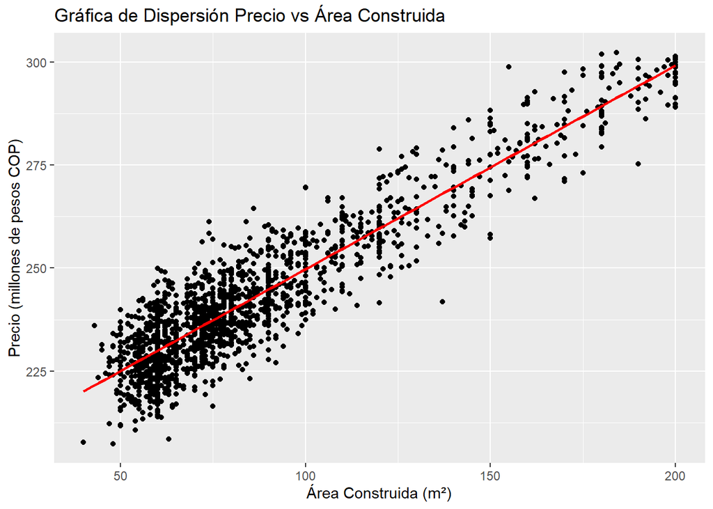

```r
# Gráfico de dispersión (preciom vs areaconst)
ggplot(vivienda4, aes(x = areaconst, y = preciom)) +
  geom_point() +
  geom_smooth(method = "lm", color = "red", se = FALSE) +  # Línea de tendencia
  labs(x = "Área Construida (m²)", y = "Precio (millones de pesos COP)") +
  ggtitle("Gráfica de Dispersión Precio vs Área Construida")
```